# Exploratory Data Analysis

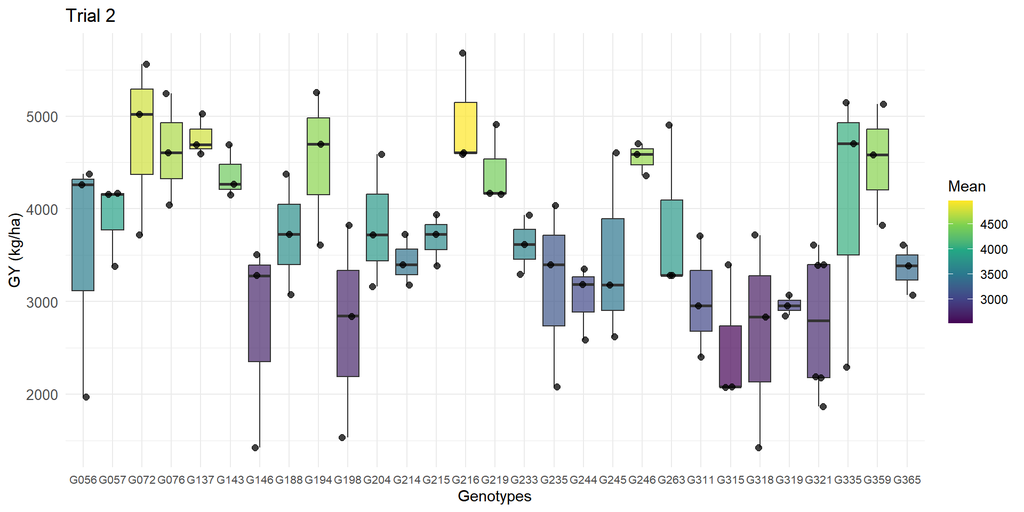

Figure 32: Trial 2 Genotypes Boxplot - Grain Yield

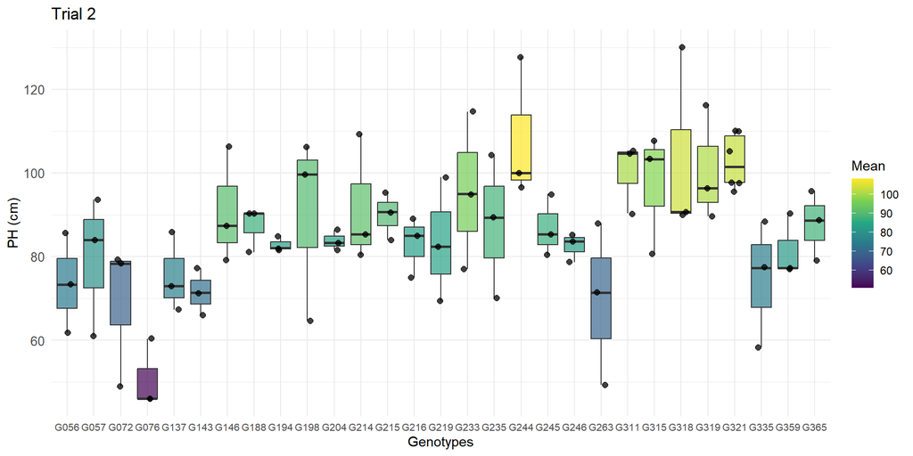

Figure 33: Trial 2 Genotypes Boxplot - Plant Height

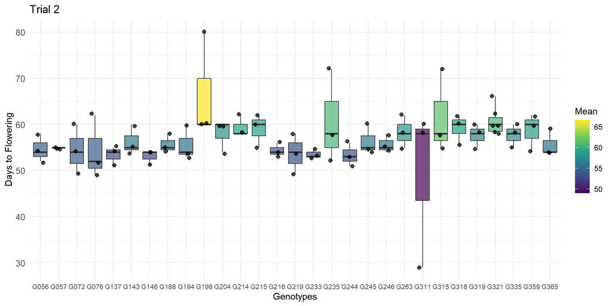

Figure 34: Trial 2 Genotypes Boxplot - Flowering Days

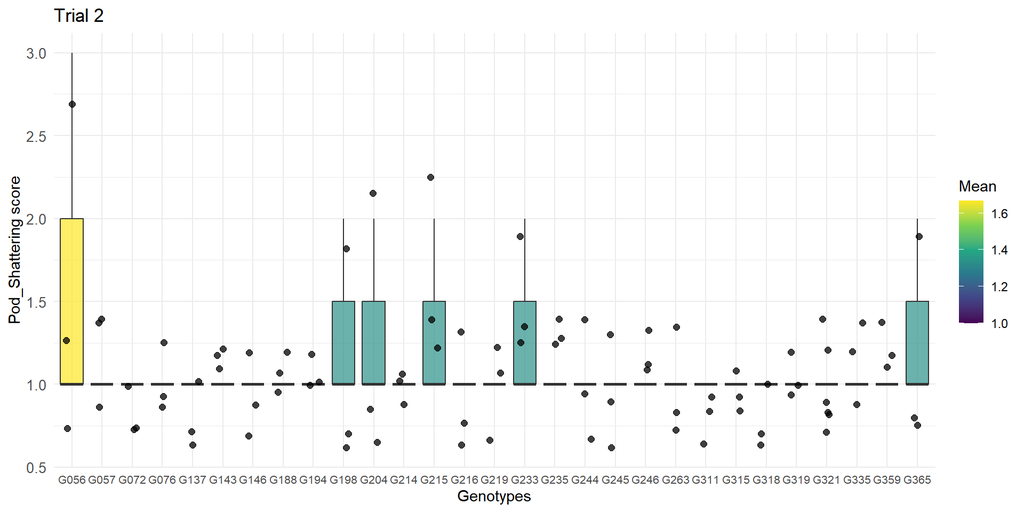

Figure 35: Trial 2 Genotypes Boxplot - Pod Shattering

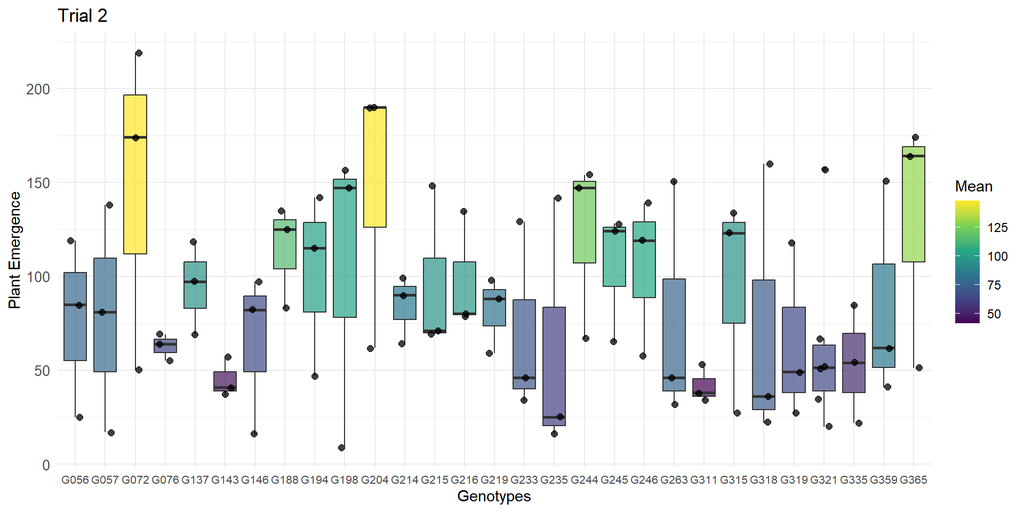

Figure 36: Trial 2 Genotypes Boxplot - Plant Emergence

# Trial 3 - Local “L074” / Year “2023”

As in the other trials, the correlation values between the traits analysed were also low. The biggest correlation observed was with plant emergence (PL_EMERG_COUNT) and pod shattering, with a value around 0.34. This value is low, and does not suggest a strong relationship between the variables.

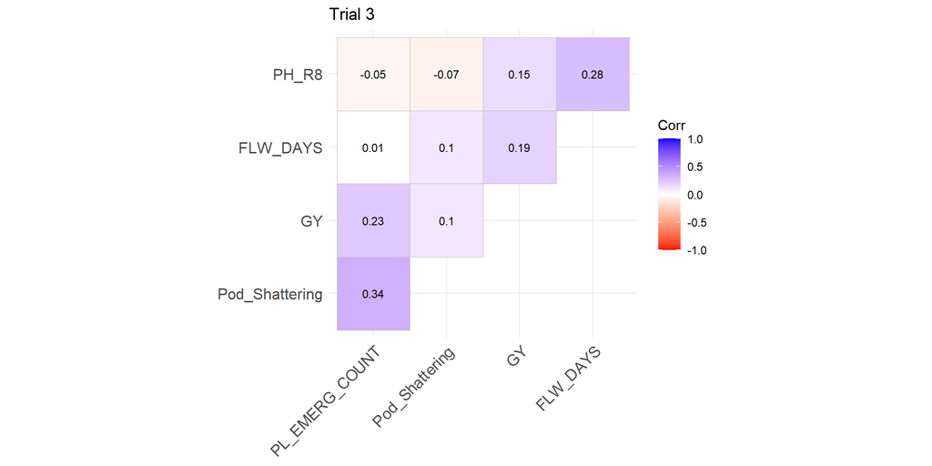

Figure 37: Trial 3 - Traits Correlation

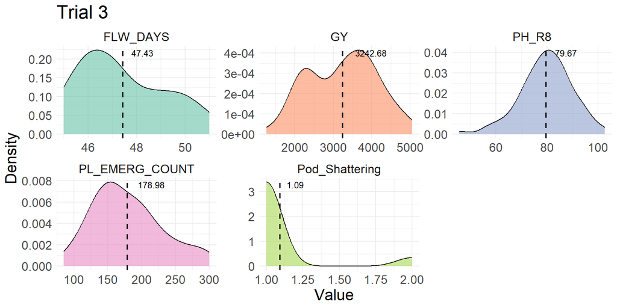

Figure 38: Trial 3 - Traits Density Plot

Analysing the grain yield (GY) information displayed in Figure 40, Figure 38 and Figure 39, it can be seen that this trial was more productive than the first one, although the values were not higher than in Trial 4. Regarding days to flowering (FLW_DAYS), the mean value was lower than on the previous trials, indicating that the genotypes in this environment may have an early flowering or shorter cycles, even though it can be seen a genetic variation of this trait in Figure 38. Looking at plant height (PH_R8), the distribution is similar to a normal, and the mean value is slightly smaller than the observed in trials 2 and 4, indicating that this environment may result in shorter plants. For plant emergence (PL_EMERG_COUNT), the mean value is next to 180, however, there is a large variation in this trait, which can be caused by differences in seed germination and vigor, or operational issues during planting. Finally, analyzing pod shattering, it is noticeable that most of the genotypes were scored as “1”, while only 6 genotypes were scored as “2”, showing that, in this trial, there were no major issues with pod shattering. The “unusual values” shown in the Figure 39 for grain yield and pod shattering were not removed because they are possible values.

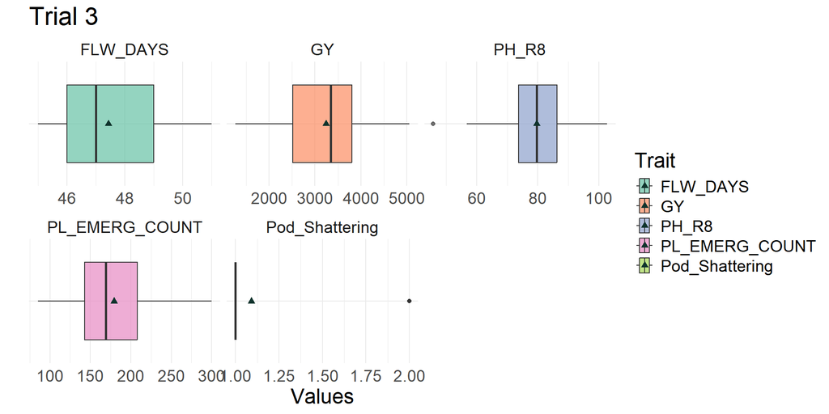

Figure 39: Trial 3 - Traits Boxplot

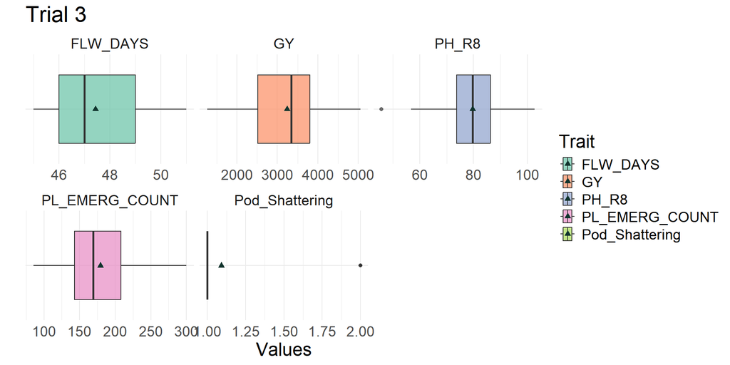

Looking into the pairwise scatter plots, clear patterns can not be detected, as the correlation values in this trial, for the traits selected, are low.

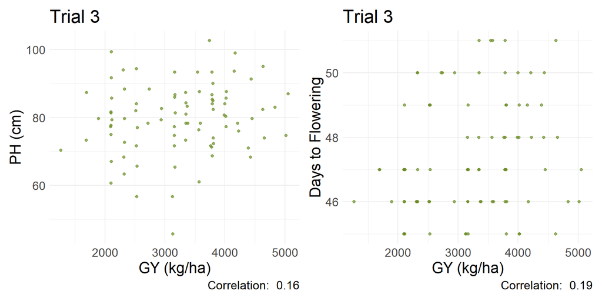

Figure 41: Trial 3 - Scatter Plots

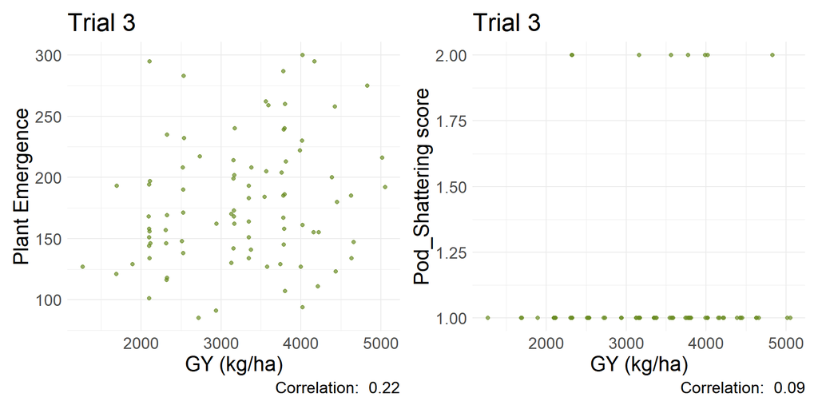

Figure 42: Trial 3 - Scatter Plots

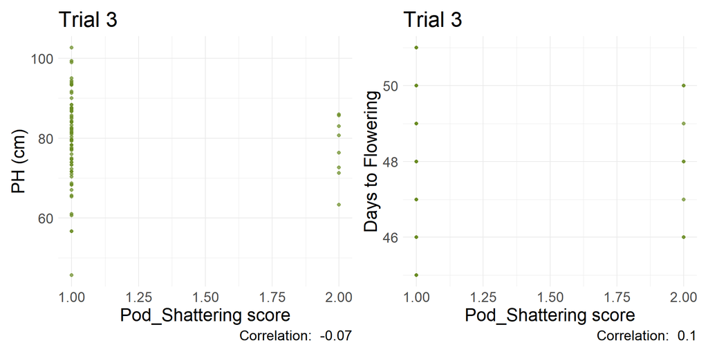

Figure 43: Trial 3 - Scatter Plots

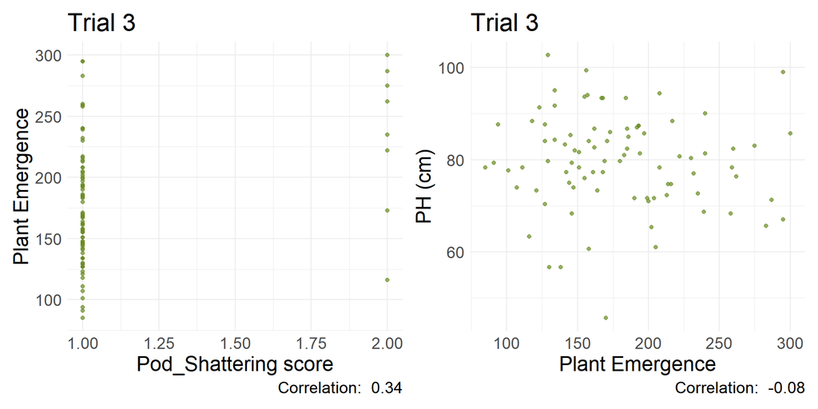

Figure 44: Trial 3 - Scatter Plots

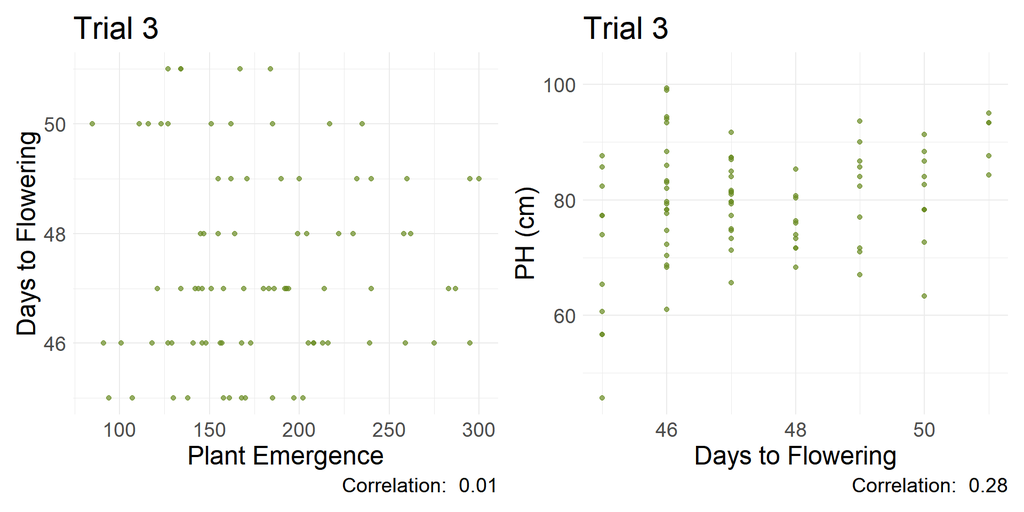

Figure 45: Trial 3 - Scatter Plots

In trial 3, the grain yield (GY) information was also analysed at genotype level, as shown in Figure 46. There were genotypes with mean yield around 2,000 kg/ha and others with means superior to 4000 kg/ha, indicating that the performance of genotypes are different in this environment. Besides that, it can be seen that in some cases, there is a considerable variation within genotype level, which can be caused by several agronomical, climate and other environmental effects. Ideally, the experimental design and the statistical analysis should be able to deal with this variation. For other traits, the variation within genotypes and across genotypes can also be seen. For example, in plant emergence ( Figure 50), there were genotypes with very slightly variations, while others had almost 50% variation.

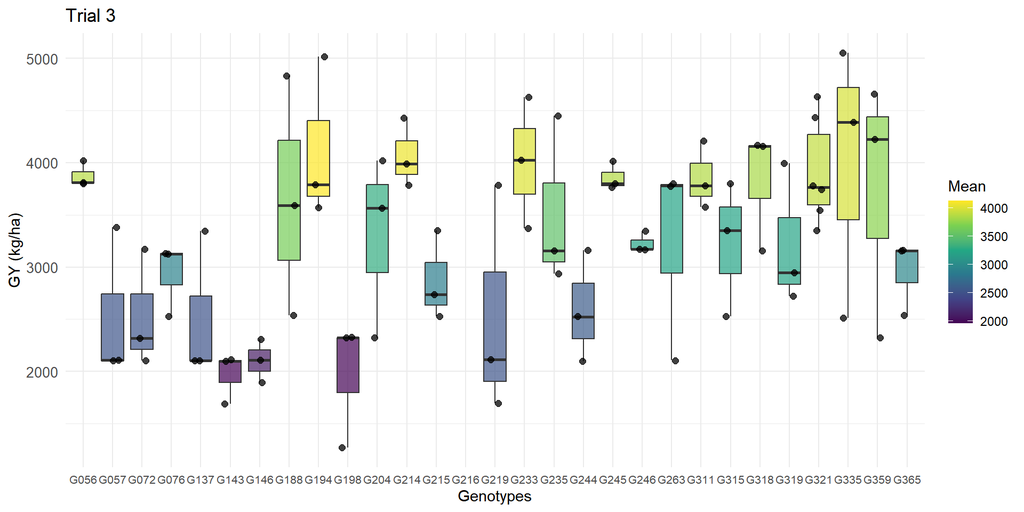

Figure 46: Trial 3 Genotypes Boxplot - Grain Yield

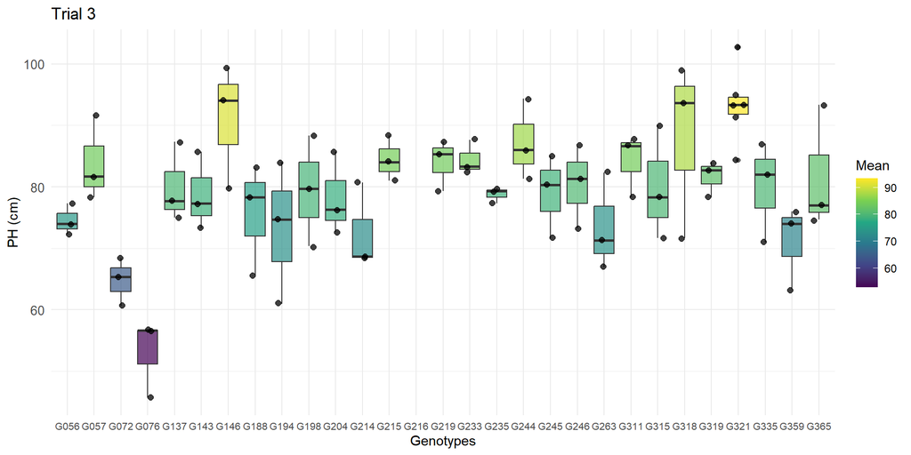

Figure 47: Trial 3 Genotypes Boxplot - Plant Height

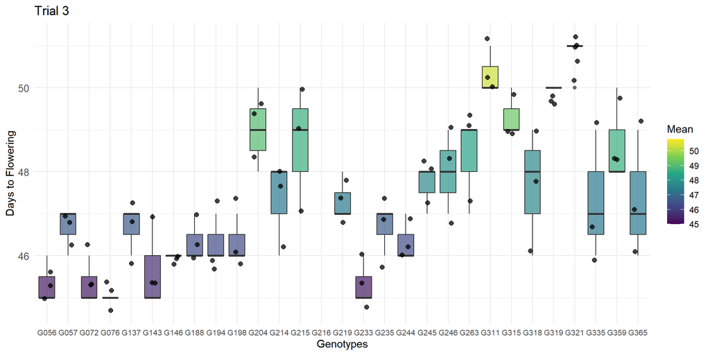

Figure 48: Trial 3 Genotypes Boxplot - Flowering Days

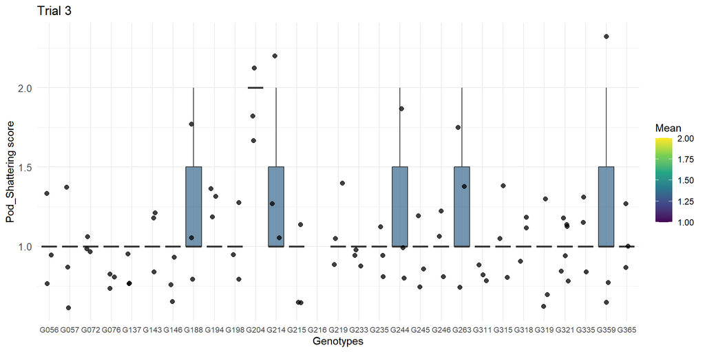

Figure 49: Trial 3 Genotypes Boxplot - Pod Shattering

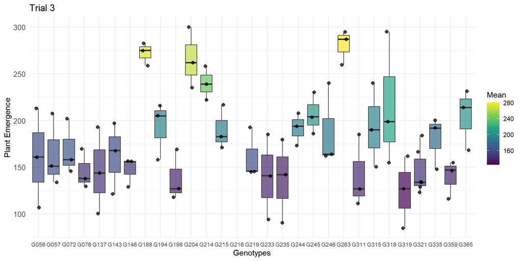

Figure 50: Trial 3 Genotypes Boxplot - Plant Emergence

# Trial 4 - Local “L0134” / Year “2023”

In Trial 4 (Location L0134), the phenotypic analysis reveals a lack of strong associations between characters, with the highest correlation observed between Grain Yield (GY) and Plant Height (PH) at a weak value of r = 0.19 ( Figure 51). This independence between traits is further elucidated by the density distributions ( Figure 52). The flowering data (FLW) shows a bimodal distribution with two prominent peaks, indicating a clear division of the population into two distinct maturation groups under these environmental conditions.

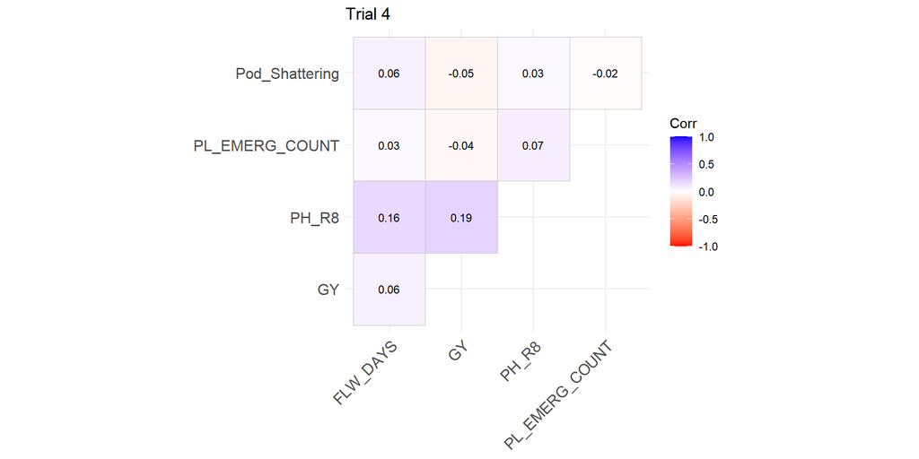

Figure 51: Trial 4 - Traits Correlation

Regarding Grain Yield (GY), the density curve is nearly flat at the top, reflecting high variability and the absence of a dominant performance trend among genotypes. While PH shows a more defined peak compared to other traits, its weak correlation with GY suggests that height was not a limiting or determining factor for productivity in this trial. Overall, the dispersed nature of the yield data and the varied density profiles indicate that at L0134, genotypic performance was highly decentralized, with different traits responding independently to environmental stimuli.

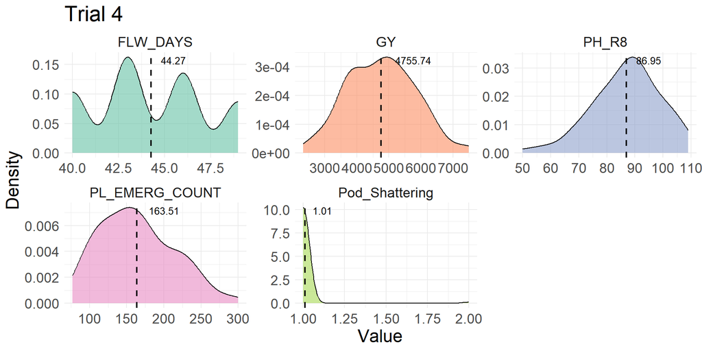

Figure 52: Trial 4 - Traits Density Plot

Complementing this, the boxplots ( Figure 53) identify potential outliers for PH, Plant Emergence, and Pod Shattering, each represented by a single data point positioned away from the main distribution. In contrast, FLW and GY do not exhibit such atypical values, showing more continuous distributions. Furthermore, the scatterplots confirm the lack of a clear linear trend between GY and the other agronomic traits ( Figure 55; Figure 56). Although the correlation between PH and GY was the highest recorded in this trial, its low magnitude (0.19) reinforces that, in this specific location, traditional yield components did not act as strong predictors for final output.

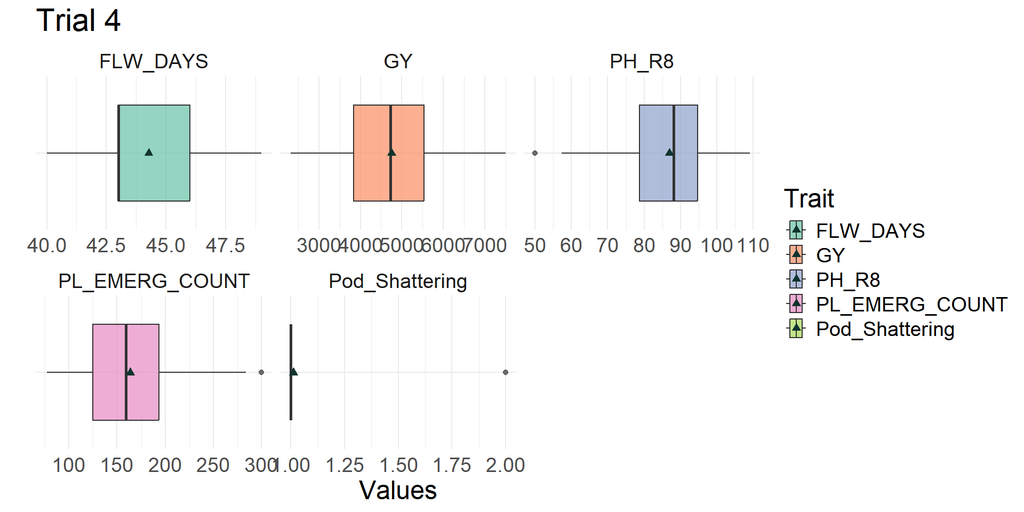

Figure 53: Trial 4 - Traits Boxplot

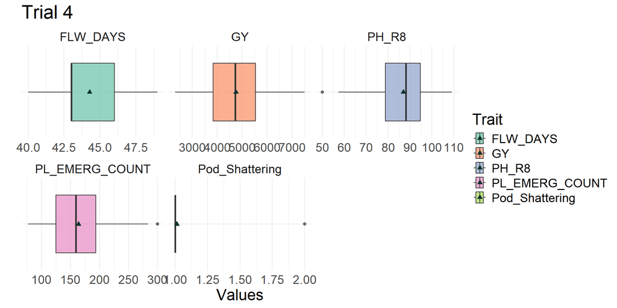

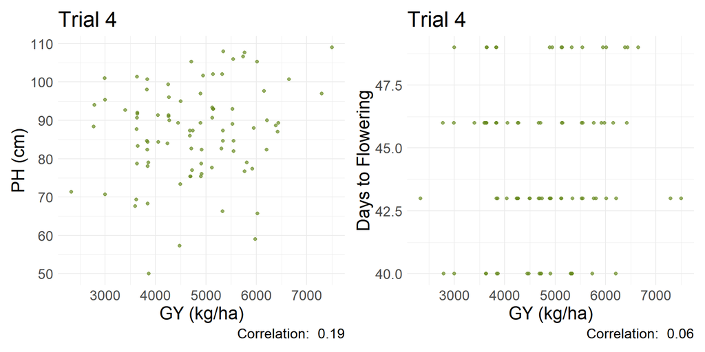

Figure 55: Trial 4 - Scatter Plots

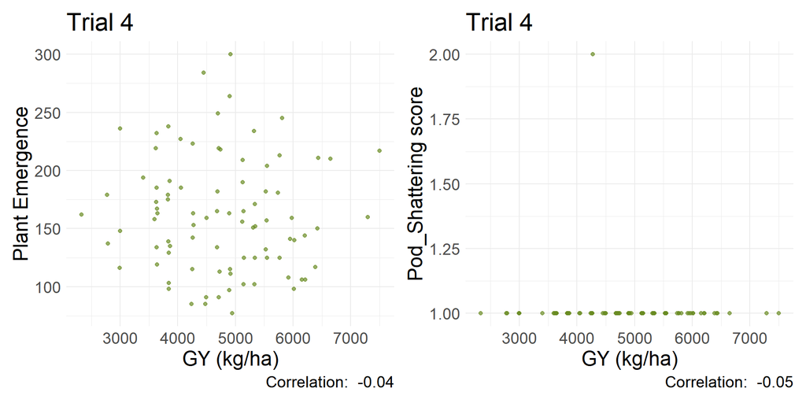

Figure 56: Trial 4 - Scatter Plots

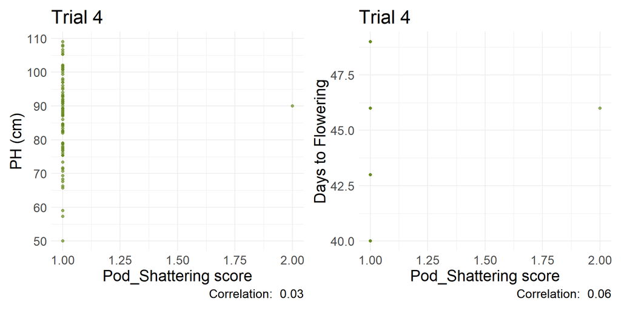

Figure 57: Trial 4 - Scatter Plots

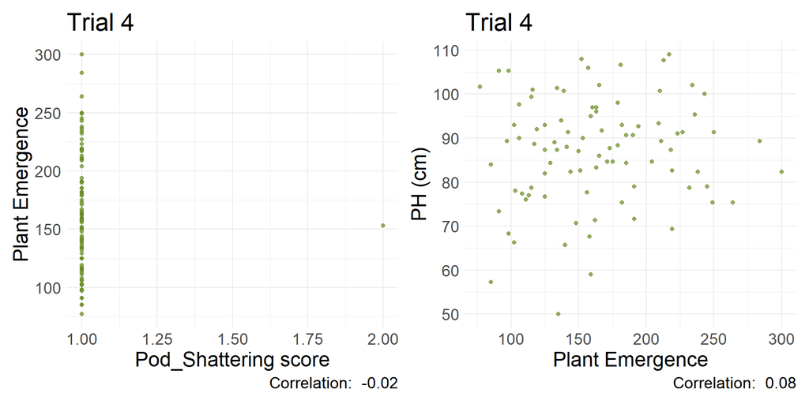

Figure 58: Trial 4 - Scatter Plots

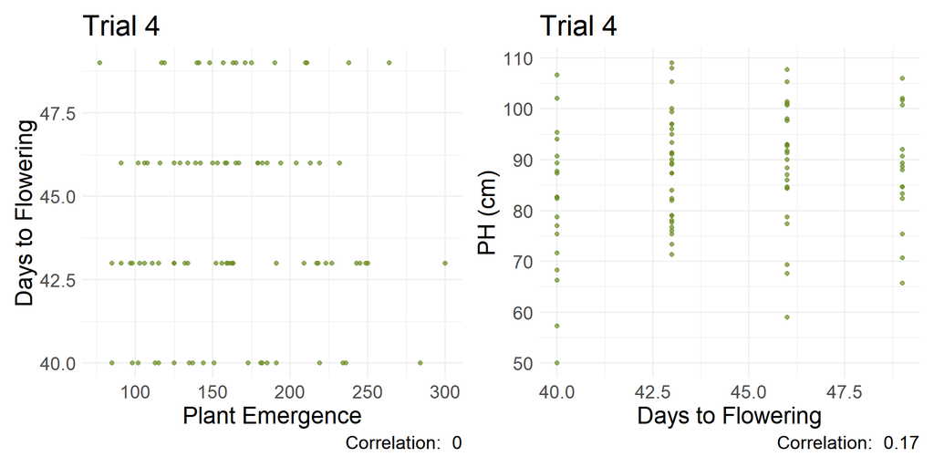

Figure 59: Trial 4 - Scatter Plots

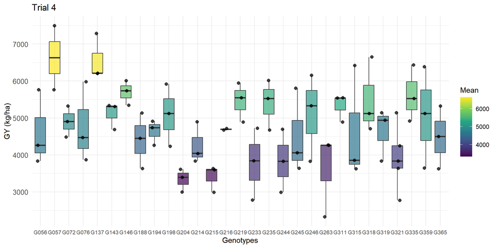

Figure 60: Trial 4 Genotypes Boxplot - Grain Yield

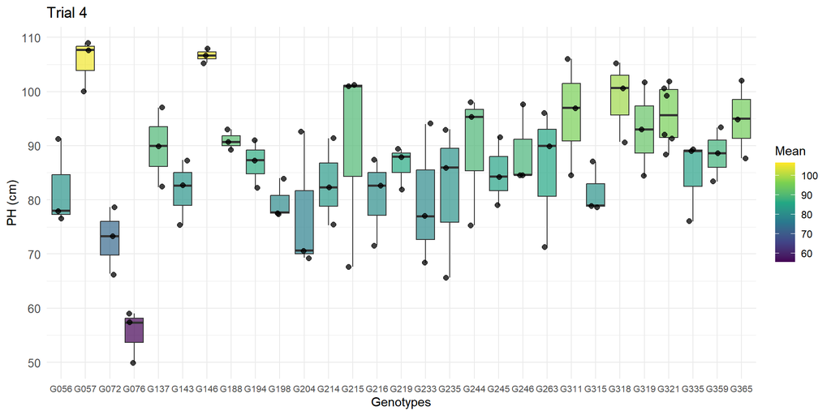

Figure 61: Trial 4 Genotypes Boxplot - Plant Height

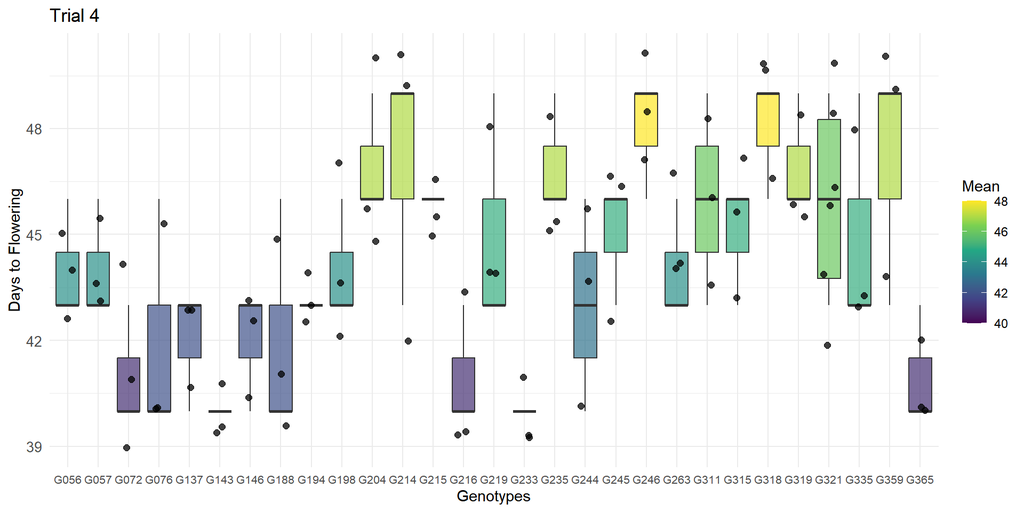

Figure 62: Trial 4 Genotypes Boxplot - Flowering Days

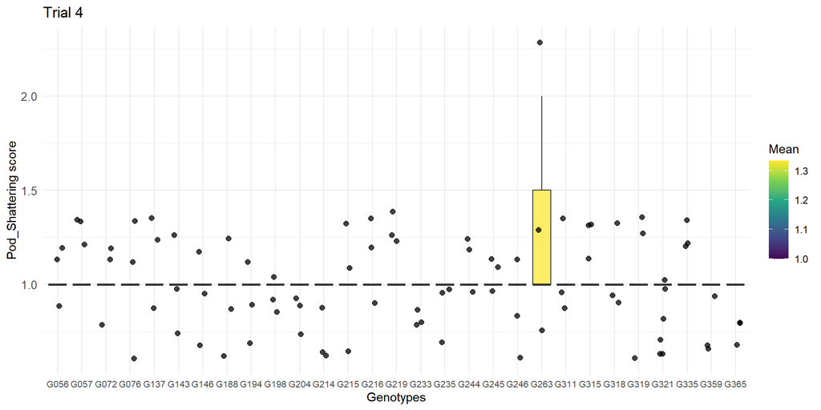

Figure 63: Trial 4 Genotypes Boxplot - Pod Shattering

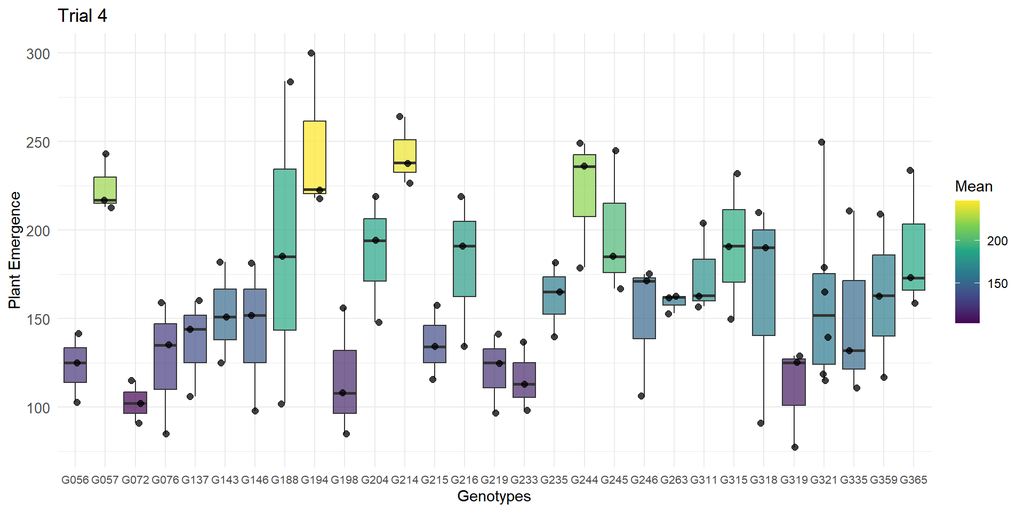

Figure 64: Trial 4 Genotypes Boxplot - Plant Emergence

# Conclusion